# Homework 09

Guides an agent through how to analyze a dataset using SVM model fitting

The kernel-tuning question moved here from Homework 08. A solution for Question 1 will be available after Monday, October 26, 2026. No solution will be provided for Question 2.

## Question 1: Choosing an SVM kernel

Use `saheart.csv` from the combined ZIP. As in Homework 7, predict `chd` using the same nine predictors, coding `famhist` as 1 for `Absent` and 2 for `Present`.

Compare SVMs with a linear kernel, polynomial kernels of degrees 2 (quadratic), 3, and 4, and a radial basis kernel. Choose **no more than 20 candidate settings in total** across these kernels. Vary the cost $C$ for each kernel and the radial scale $\gamma$ for the radial kernel. State any other kernel settings you hold fixed.

Divide the observations into five folds yourself and use the same folds for all candidates. Standardize predictors using only the fitting observations in each fold. Report the candidate settings and their mean cross-validation misclassification rates. Which kernel and settings do you prefer? Give a brief justification.

## Solution for Question 1

```r
library(e1071)
d <- read.csv("data/saheart.csv")
d$famhist <- ifelse(d$famhist == "Present", 2, 1)
d$chd <- factor(d$chd)
predictors <- setdiff(names(d), "chd")
p <- length(predictors)

#five folds
set.seed(9)
fold <- sample(rep(1:5, length.out = nrow(d)))
table(fold)
```

```
fold
 1  2  3  4  5
93 93 92 92 92
```

## Candidate settings ~ 20

Kernel | Settings varied | Held fixed |  
Linear | $C \in \{0.01, 0.1, 1\}$ (3) | none |  
Polynomial, degree 2, 3, 4 | $C \in \{0.01, 0.1, 1\}$ for each degree (9) | $\gamma = 1/9$, `coef0` $= 1$ |  
Radial | $C \in \{1, 10\}$, $\gamma \in \{0.01, 0.03, 0.1, 0.3\}$ (8) | none |

```r
cand <- rbind(
  data.frame(kernel = "linear", degree = NA, cost = c(0.01, 0.1, 1), gamma = NA),
  expand.grid(kernel = "polynomial", degree = 2:4, cost = c(0.01, 0.1, 1), gamma = NA),
  expand.grid(kernel = "radial", degree = NA, cost = c(1, 10),
              gamma = c(0.01, 0.03, 0.1, 0.3))
)
stopifnot(nrow(cand) <= 20)
```

```r
#cross validation
cv_error <- function(kernel, degree, cost, gamma) {
  sapply(1:5, function(f) {
    train <- d[fold != f, ]
    test  <- d[fold == f, ]
    mu <- colMeans(train[predictors])
    sg <- apply(train[predictors], 2, sd)
    train[predictors] <- scale(train[predictors], mu, sg)
    test[predictors]  <- scale(test[predictors],  mu, sg)

    args <- list(chd ~ ., data = train, kernel = kernel, cost = cost, scale = FALSE)
    if (kernel == "polynomial") args <- c(args, degree = degree, gamma = 1 / p, coef0 = 1)
    if (kernel == "radial")     args$gamma <- gamma
    fit <- do.call(svm, args)

    mean(predict(fit, test) != test$chd)
  })
}

errs <- mapply(cv_error, as.character(cand$kernel), cand$degree, cand$cost, cand$gamma,
               SIMPLIFY = FALSE)
cand$cv_error <- sapply(errs, mean)
cand$se       <- sapply(errs, sd) / sqrt(5)
```

## Results

```r
out <- cand[order(cand$cv_error), ]
knitr::kable(out, digits = 3, row.names = FALSE,
             col.names = c("Kernel", "Degree", "C", "Gamma", "Mean CV error", "SE"))
```

| Kernel | Degree | C | Gamma | Mean CV error | SE |
| --- | --- | --- | --- | --- | --- |
| linear | NA | 0.10 | NA | 0.268 | 0.013 |
| radial | NA | 1.00 | 0.01 | 0.273 | 0.013 |
| polynomial | 2 | 1.00 | NA | 0.275 | 0.011 |
| linear | NA | 1.00 | NA | 0.275 | 0.021 |
| polynomial | 2 | 0.10 | NA | 0.277 | 0.013 |
| radial | NA | 1.00 | 0.03 | 0.279 | 0.007 |
| polynomial | 4 | 0.10 | NA | 0.279 | 0.011 |
| radial | NA | 10.00 | 0.01 | 0.281 | 0.016 |
| polynomial | 3 | 0.10 | NA | 0.284 | 0.013 |
| radial | NA | 10.00 | 0.10 | 0.286 | 0.015 |
| polynomial | 4 | 0.01 | NA | 0.290 | 0.015 |
| polynomial | 3 | 1.00 | NA | 0.290 | 0.007 |
| polynomial | 4 | 1.00 | NA | 0.296 | 0.014 |
| linear | NA | 0.01 | NA | 0.299 | 0.026 |
| radial | NA | 10.00 | 0.03 | 0.303 | 0.011 |
| radial | NA | 1.00 | 0.10 | 0.303 | 0.016 |
| radial | NA | 1.00 | 0.30 | 0.318 | 0.011 |
| polynomial | 3 | 0.01 | NA | 0.331 | 0.005 |
| polynomial | 2 | 0.01 | NA | 0.340 | 0.008 |
| radial | NA | 10.00 | 0.30 | 0.359 | 0.017 |

```r
aggregate(cv_error ~ kernel, data = cand, FUN = min)
```

```
      kernel  cv_error
1     linear 0.2684666
2 polynomial 0.2749649
3     radial 0.2727443
```

I prefer the linear kernel with $C = 0.1$, which has the lowest mean CV misclassification rate (about 0.268).

The best settings of the other kernels are still pretty close. Ex, radial ($\gamma = 0.01$, $C = 1$) at about 0.273, quadratic ($C = 1$) at about 0.275, and the best degree-3 and degree-4 settings at about 0.28 to 0.29. These gaps are smaller than the fold-to-fold standard errors (mostly about 0.01 to 0.02), so no kernel is largely better. Since the nonlinear kernels give no real gain, the simplest model is the best choice. It has the fewest tuning parameters, is the least likely to have overfitting, and is the easiest to interpret. Very small $C$ (0.01) results in underfitting for linear and polynomial kernels, and large $\gamma$ with large $C$ overfits for the radial kernel.

## Question 2: Write and use a short SVM analysis skill

In Homework 8, you reviewed another student’s skill. Review the comments and suggestions you received on your own Homework 7 skill. Use what you learned from both sides of the peer review to write a new, shorter skill for SVM model fitting.

**Write the skill by hand.** Create a `SKILL.md` with a short name and description in YAML frontmatter. Write the entire file yourself, without asking AI to draft or edit it. The instruction body after the closing `---` of the frontmatter must be **no more than 50 lines**, including blank lines. Keep the skill independent of any particular dataset, variable names, or observed results, and load it only when you explicitly invoke it.

Your skill should direct the agent to:

1. judge whether the data are suitable for an SVM analysis;
2. choose which kernels to consider and explain why;
3. identify tuning parameters and a method for tuning them;
4. choose an evaluation method that supports selecting a final model;
5. require a compact figure and table that justify the choices;
6. interpret the fit and report the key numerical results; and
7. prioritize the evidence needed to justify the final model in **no more than one printed page at 11-point font**.

**Apply the skill.** Explicitly invoke your skill to analyze `saheart.csv`, using the same response, nine predictors, and `famhist` coding as in Question 1. Provide these data details when invoking the skill, not in the skill itself. Let the skill guide the analysis, then check the resulting report and calculations.

**Submit the results.** Include the one-page, 11-point analysis report in your Homework 09 submission and append the complete contents of your `SKILL.md` afterward. The appended skill is outside the one-page limit.

## Solution for Question 2

**Contents of SKILL.md**

1. Define the prediction task and outcome, available sample size, feature types, missingness, class balance or target distribution, dependence, and deployment goal. Assess whether an SVM is suitable given data quality, scaling, computational cost, and interpretability needs. Highlight or explain concerns or recommend an alternative if unsuitable.
2. Choose candidate kernels before inspecting final test results. Consider linear for a simple baseline and high-dimensional data, RBF for flexible nonlinear relationships, and polynomial only when interactions justify it.
3. Split off a representative untouched test set when possible. Use stratified, grouped, or time-aware splits as the data require. Putencoding, scaling, and any feature selection inside each training fold to prevent leakage.
4. Tune C and kernel-specific parameters (gamma for RBF; degree, gamma, and coefficient for polynomial) for regression also tune epsilon. Use a justified grid or randomized search with cross-validation, a task-appropriate metric, and a simple baseline. Handle imbalance with suitable metrics and, if warranted, tune class weights within training folds.
5. Select a final model using cross-validation results and uncertainty, complexity, and practical tradeoffs. Refit the selected on all training data and evaluate once on the untouched test set. If a test set is not feasible, use nested cross-validation for an assessment and explain the limitation. Make sure to distinguish selection scores from final performance.
6. Include one compact figure showing the relevant validation tradeoff or diagnostic and one compact table comparing candidate kernels and baseline, tuning choices, and evaluation scores. Label metrics, splits, and uncertainty where available; make the evidence for the selection clear.
7. Interpret the fit in context, so report the selected kernel, parameters, sample sizes, preprocessing, validation scheme, selection metric, and final performance with uncertainty. For classification, report relevant class-specific results and a confusion matrix. For regression, report relevant error measures. Discuss limitations and avoid causation claims. Explain linear coefficients only on an appropriate scale.
8. Output the justification, figure, table, interpretation, and limitations in at most one printed page at 11-point font. If the page is too long, then prioritize including evidence that distinguishes the final model

**end of skill file contents**

# SAheart: predicting coronary heart disease with SVMs

n = 462 complete observations; outcome chd (0 = no, 1 = yes); predictors: sbp, tobacco, ldl, adiposity, famhist, typea, obesity, alcohol, age. famhist: Absent = 1, Present = 2. Class 1 prevalence: 34.6%.

**Suitability and design.** Nine numeric predictors and no missing values make an SVM suitable after scaling. These are patient-level cross-sectional data; no group or time structure is supplied. I reserved a stratified 20% test set (93 people; 32 with CHD) before selection. On the other 369 observations, I used the same shuffled stratified five folds (seed 9) for all candidates. Each fold fits its own standardizer through a pipeline, avoiding preprocessing leakage.

**Candidate grid and selection.** The 20 SVM settings were fixed before testing: linear, C ∈ {0.01, 0.1, 1}; polynomial degrees 2–4, each C ∈ {0.01, 0.1, 1}, gamma = 1/9 and coef0 = 1; RBF, C ∈ {1, 10} and gamma ∈ {0.01, 0.03, 0.1, 0.3}. I minimized mean fold misclassification and used a one-SE rule to prefer the simplest kernel within one SE of the best. Error bars below are fold standard error; the dashed line is the best error plus its SE.

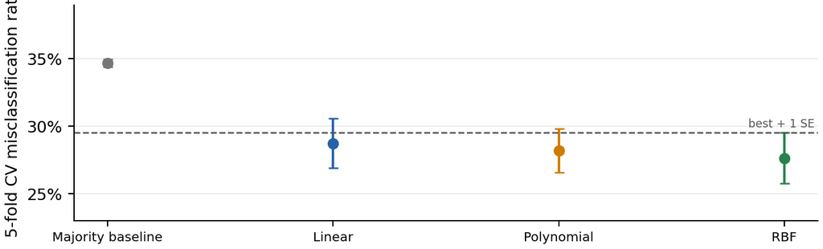

| model | setting | Mean CV error (SE) |
| --- | --- | --- |
| Majority baseline | Predict class 0 | 34.7% (0.3%) |
| Linear | Linear, C=0.1 | 28.7% (1.8%) |
| Polynomial | Polynomial degree=2, C=0.1, gamma=1/9, coef0=1 | 28.2% (1.6%) |
| RBF | RBF, C=10, gamma=0.01 | 27.6% (1.9%) |

**Choice:** the raw CV minimum is RBF, C=10, gamma=0.01 at 27.6% error (SE 1.9%). The simpler Linear, C=0.1 is within one SE (29.5% cutoff), so I select it. Its CV error is 28.7% (SE 1.8%), versus 34.7% (SE 0.3%) for the majority-class baseline. Nonlinear kernels show no clearly reliable improvement over linear within this small tuning exercise.

## One-time evaluation on untouched test data

The selected linear SVM gives 74.2% accuracy (95% Wilson CI 64.5%–82.0%) and 69.9% balanced accuracy. Sensitivity is 18/32 (56.25%); specificity is 51/61 (83.61%); precision/F1 are 64.3%/60.0%. Majority-class test accuracy is 65.6%; the selected model misses some CHD cases.

Confusion matrix (rows = actual; columns = predicted):

| Actual / predicted | Predicted 0 | Predicted 1 |
| --- | --- | --- |
| Actual 0 | 51 | 10 |
| Actual 1 | 14 | 18 |

**Limitations.** A single holdout is small and the uncertainty is substantial; the one-SE comparison is approximate, and the grid is limited. The result is a predictive association, not evidence that any risk factor causes CHD. Clinical use would require external validation and attention to the cost of missed cases.

**All 20 SVM candidate settings and cross-validation errors**

| Kernel | Setting | Mean CV error | SE |
| --- | --- | --- | --- |
| rbf | RBF, C=10, gamma=0.01 | 27.6% | 1.9% |
| poly | Polynomial degree=2, C=0.1, gamma=1/9, coef0=1 | 28.2% | 1.6% |
| poly | Polynomial degree=3, C=0.1, gamma=1/9, coef0=1 | 28.2% | 2.0% |
| rbf | RBF, C=1, gamma=0.03 | 28.2% | 1.9% |
| linear | Linear, C=0.1 | 28.7% | 1.8% |
| poly | Polynomial degree=2, C=1, gamma=1/9, coef0=1 | 29.3% | 2.4% |
| linear | Linear, C=1 | 29.3% | 2.3% |
| poly | Polynomial degree=4, C=0.1, gamma=1/9, coef0=1 | 29.5% | 1.3% |
| rbf | RBF, C=1, gamma=0.01 | 29.8% | 1.2% |
| rbf | RBF, C=10, gamma=0.03 | 31.2% | 2.6% |
| rbf | RBF, C=1, gamma=0.1 | 31.2% | 1.9% |
| linear | Linear, C=0.01 | 32.0% | 0.8% |
| poly | Polynomial degree=3, C=1, gamma=1/9, coef0=1 | 32.0% | 2.1% |
| poly | Polynomial degree=4, C=0.01, gamma=1/9, coef0=1 | 32.0% | 0.7% |
| rbf | RBF, C=1, gamma=0.3 | 33.3% | 1.7% |
| poly | Polynomial degree=3, C=0.01, gamma=1/9, coef0=1 | 33.9% | 0.8% |
| poly | Polynomial degree=2, C=0.01, gamma=1/9, coef0=1 | 34.7% | 0.3% |
| rbf | RBF, C=10, gamma=0.1 | 35.8% | 2.4% |
| poly | Polynomial degree=4, C=1, gamma=1/9, coef0=1 | 36.1% | 2.5% |
| rbf | RBF, C=10, gamma=0.3 | 38.8% | 3.5% |